# Innovation as Measured by New Patents Issued

### by Rita Rozental

### Patent counts and R&D expenditure Limitations in current metrics: A Study on the Impact of R&D Expenditure on Patent Quality The need for more nuanced measures

### **Griliches (1990):** Highlighted the use of patent counts as economic indicators. **Trajtenberg (1990):** Introduced citation-weighted patent counts. **Lim (2004):** Found that R&D is a stronger predictor for patents that are more original and have more forward citations.

### **Hall et al. (2001):** Examined trends in patenting and challenges in interpreting citation counts. **Ahuja and Lampert (2001):** Called for a greater focus on the technical novelty and economic value of patents **Moser (2005):** Patent counts might not accurately reflect true innovation. **Blind et al. (2006):** Potential limitations of using patent counts to measure R&D outcomes.

### Need for Further Research These studies collectively suggest that while patent counts are a commonly used metric, they have **significant limitations** in truly capturing the essence of innovation. The literature emphasizes the **need for more nuanced measures**, such as citation frequency and originality, to better understand the true value and impact of innovations. There's a growing consensus that a **multi-dimensional approach**, considering both **quantitative and qualitative factors**, is essential for a more accurate assessment of innovation.

### **Citation Rate:** Impact and recognition in subsequent research. **R&D Expenditure Efficiency:** Patent output relative to R&D spending. **Originality:** Novelty and uniqueness of the invention. **Industry Context:** Technological opportunities and constraint.

### 1. Industry segmentation

### 2. Normalization

### 3. Originality assessment

### 4. Comparative analysis.

### The top five U.S. pharmaceutical companies were selected based on the number of new patents filed over the past five years, as reported by the United States Patent and Trademark Office (USPTO).

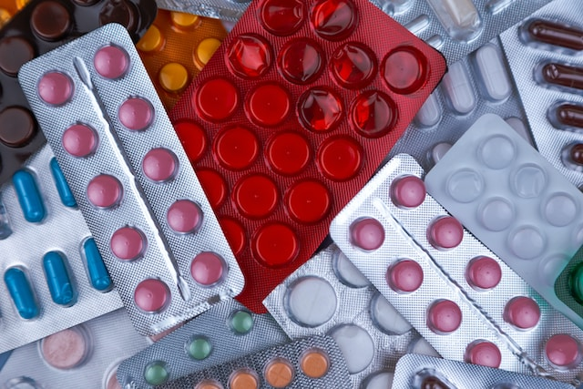

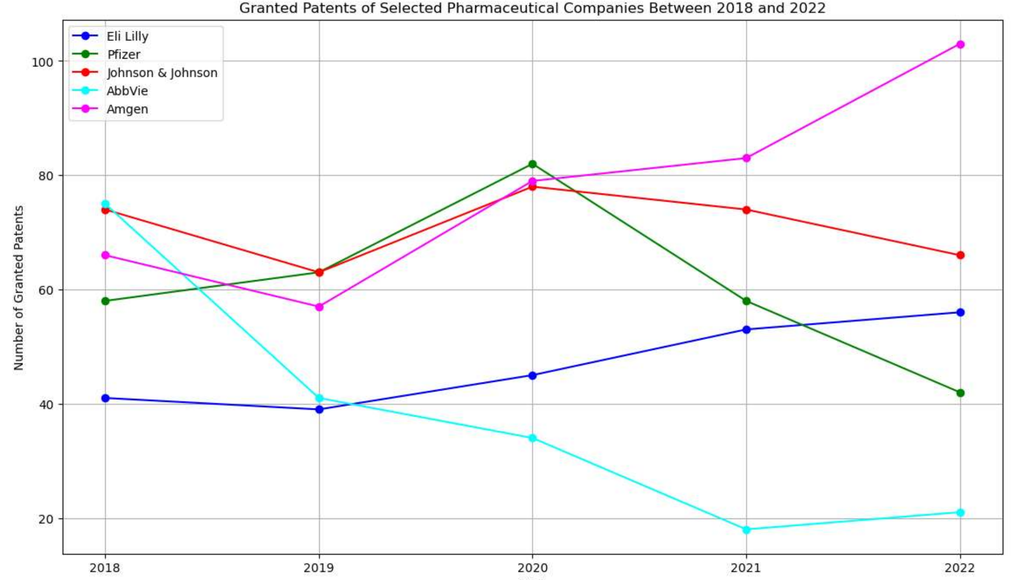

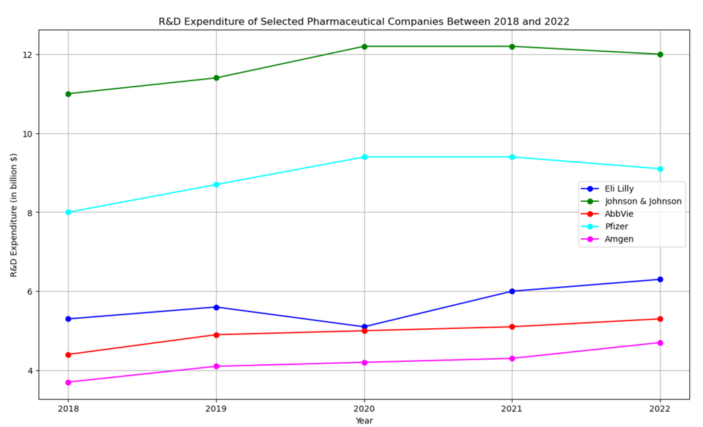

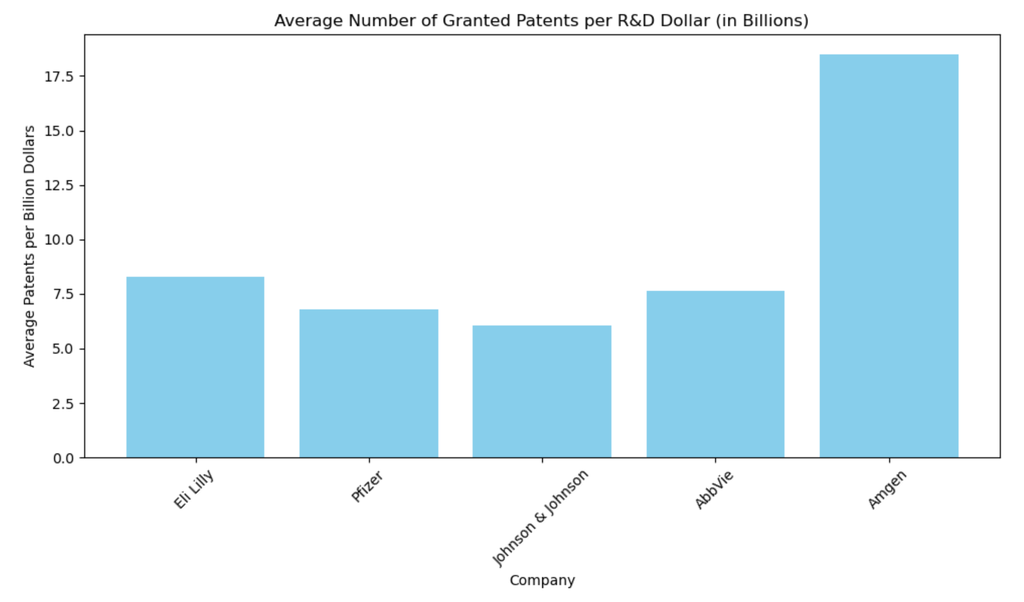

### **In the context of this study, the assessment of the USPTO was used in order to most accurately the originality of patents filed. In the USPTO approval process patents that are non-novel or not original are filtered out by the USPTO. Thus, the number of patents filed was compared with the number of patents granted to each company and used as the data for the originality metric.**

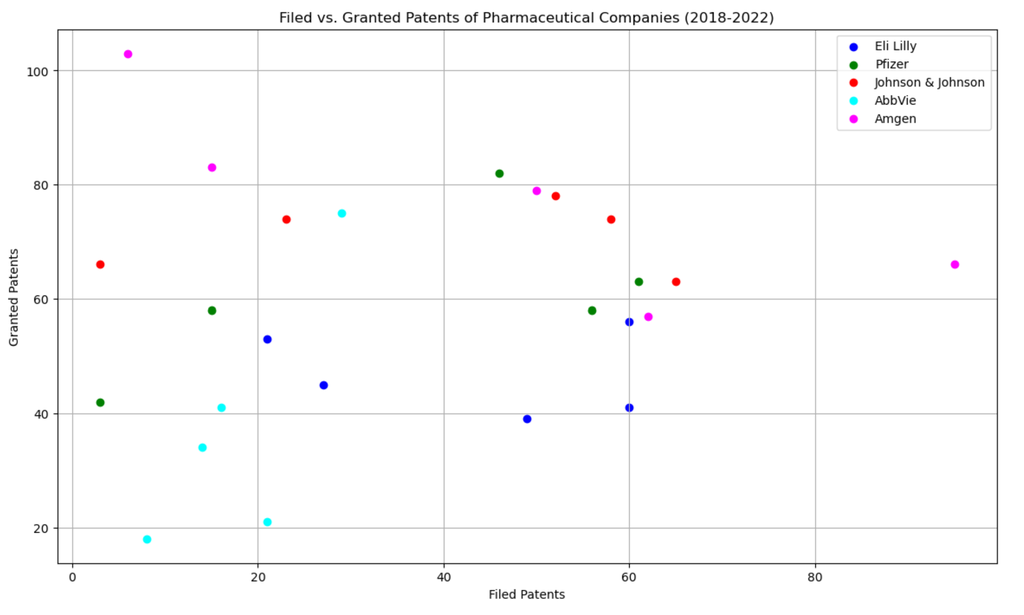

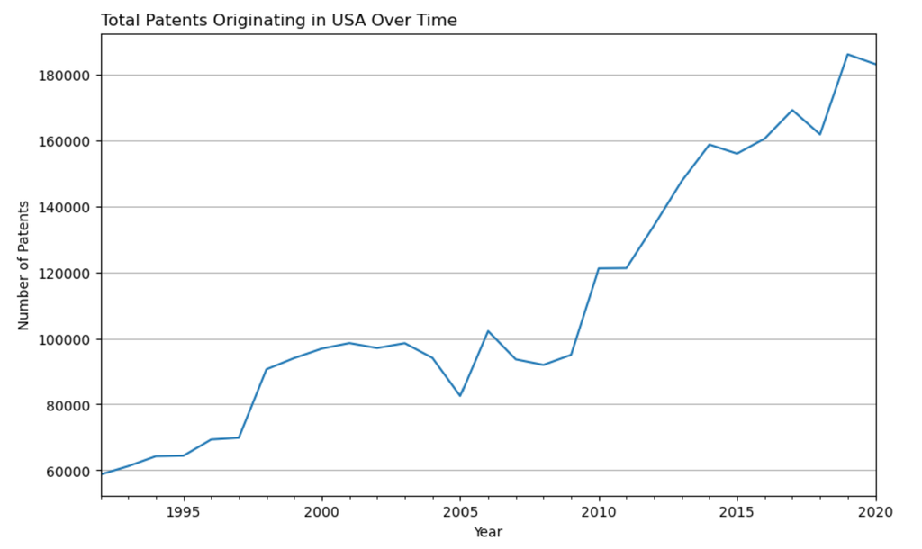

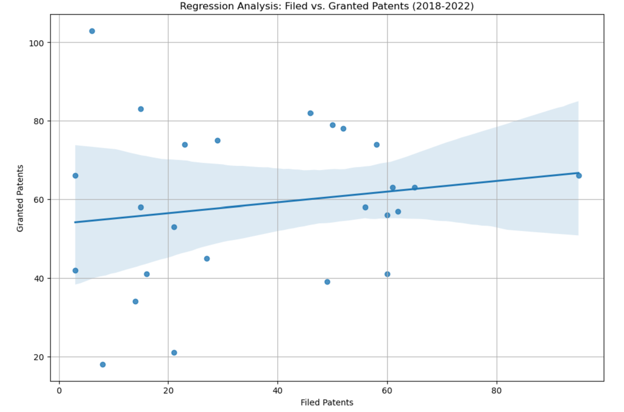